# Jimmy’s Edits

Jimmy Erkens

2023-10-29

## Jimmy Comments

Hey no worries at all I think you did great! I’ve added my comments throughout your document, feel free to see what’s up.

### 1

Check your logic if/else statements in your R function. As it stands, if you have n2 but not p2, the function is going to think you have both and will proceed with a 2-sample. I’m unsure why it’s returning NULL but triple check your statements to make sure you’re calculating the correct things (make sure phat and p0 are differentiated too). I’ve shared my repo feel free to have a look at what I’ve done. I like what you did with the alternative argument but could be a bit annoying to have to type “alternative = ‘two.sided’” when you just want to use this function for a super simple diagnostic p test.

### 2

Your plots look great and I can tell you’ve spent your time looking it over (shoutout to stack exchange). With the CIs and PIs, you’ve got to transform the brainsize variable in the aes() argument. Otherwise solid, I’d consider changing your variables that way you know what’s what (df is too vague to be useful over the course of a document).

## Reflection:

Horrible is the only word that could explain the state of my mind doing this assignment. Creating the function was fun and relatively simple. But th second part of the homework took me days to figure out, and I did not figure it out well. I struggled with keeping track of all my objects and their names as well as figuring out functions as they’re being coded. I also struggled with the exact method of plotting all the confidence and prediction intervals. Eventually, I took what I think is a basic method and made a data frame of all my plotting points and called upon each individual line. I could not figure out what I did wrong with plotting the confidence and prediction intervals for the log graph. I believe I forgot to transform the confidence intervals but I tried performing log or undoing logs on different vectors but could not. Please excuse the horrible homework assignment, I had a lot on my plate this week.

## Question 2: Kamilar and Cooper Data

```r
f <- curl("https://raw.githubusercontent.com/fuzzyatelin/fuzzyatelin.github.io/master/AN588_Fall23/KamilarAndCooperData.csv")
d <- read.csv(f)
summary(d)
```

```
##  Scientific_Name       Family             Genus             Species
##  Length:213         Length:213         Length:213         Length:213
##  Class :character   Class :character   Class :character   Class :character
##  Mode  :character   Mode  :character   Mode  :character   Mode  :character
##
##
##
##
##  Brain_Size_Species_Mean Brain_Size_Female_Mean Brain_size_Ref
##  Min.   :  1.63          Min.   :  1.66         Length:213
##  1st Qu.: 13.95          1st Qu.: 13.23         Class :character
##  Median : 61.45          Median : 57.20         Mode  :character
##  Mean   : 68.11          Mean   : 65.24
##  3rd Qu.: 88.48          3rd Qu.: 86.80
##  Max.   :491.27          Max.   :480.15
##  NA's   :42              NA's   :48
##  Body_mass_male_mean Body_mass_female_mean Mass_Dimorphism   Mass_Ref
##  Min.   :    31      Min.   :   30.0       Min.   :0.841   Length:213
##  1st Qu.:   865      1st Qu.:  835.5       1st Qu.:1.013   Class :character
##  Median :  4290      Median : 3039.0       Median :1.109   Mode  :character
##  Mean   :  8112      Mean   : 5396.5       Mean   :1.246
##  3rd Qu.:  7815      3rd Qu.: 6390.0       3rd Qu.:1.409
##  Max.   :170400      Max.   :97500.0       Max.   :2.688
##  NA's   :18          NA's   :18            NA's   :18
##  MeanGroupSize     AdultMales      AdultFemale     AdultSexRatio
##  Min.   : 1.00   Min.   : 0.900   Min.   : 1.000   Min.   : 0.500
##  1st Qu.: 4.00   1st Qu.: 1.000   1st Qu.: 1.000   1st Qu.: 1.000
##  Median : 7.80   Median : 1.500   Median : 2.900   Median : 1.450
##  Mean   :15.06   Mean   : 2.516   Mean   : 5.049   Mean   : 2.305
##  3rd Qu.:18.50   3rd Qu.: 3.100   3rd Qu.: 7.100   3rd Qu.: 2.770
##  Max.   :90.00   Max.   :16.000   Max.   :25.200   Max.   :15.600
##  NA's   :60      NA's   :68       NA's   :68       NA's   :84
##  Social_Organization_Ref InterbirthInterval_d   Gestation       WeaningAge_d
##  Length:213              Min.   : 144.5       Min.   : 59.99   Min.   :  40.0
##  Class :character        1st Qu.: 365.0       1st Qu.:142.00   1st Qu.: 122.4
##  Mode  :character        Median : 476.9       Median :165.04   Median : 237.7
##                          Mean   : 572.1       Mean   :163.47   Mean   : 310.0
##                          3rd Qu.: 741.4       3rd Qu.:180.75   3rd Qu.: 383.4
##                          Max.   :2007.5       Max.   :256.00   Max.   :1260.8
##                          NA's   :103          NA's   :75       NA's   :95
```

[output cut: 41 more lines]

```
##  Min.   : 9.00   Min.   : 3.00   Min.   : 4.00   Min.   : 0.900
##  1st Qu.:21.75   1st Qu.:14.93   1st Qu.:18.38   1st Qu.: 3.500
##  Median :33.30   Median :21.00   Median :30.48   Median : 5.400
##  Mean   :33.08   Mean   :21.67   Mean   :34.26   Mean   : 7.369
##  3rd Qu.:43.08   3rd Qu.:26.90   3rd Qu.:52.40   3rd Qu.:10.000
##  Max.   :63.90   Max.   :70.60   Max.   :78.50   Max.   :23.500
##  NA's   :141     NA's   :143     NA's   :143     NA's   :136
##  Activity_Budget_Ref
##  Length:213
##  Class :character
##  Mode  :character
##
##
##
##
```

```r
d <- d %>% select(c(Brain_Size_Species_Mean, MaxLongevity_m)) #isolate needed data set columns
#Used to filter data frame: https://dplyr.tidyverse.org/reference/select.html
d <- na.omit(d) # ^head's up you don't need to get rid of columns for this -Jimmy
# personally I would use more detailed variable names "d" could be anything -Jimmy
linmodel <- lm(data = d, MaxLongevity_m ~ Brain_Size_Species_Mean)
linmodel
```

```
##
## Call:
## lm(formula = MaxLongevity_m ~ Brain_Size_Species_Mean, data = d)
##
## Coefficients:
##             (Intercept)  Brain_Size_Species_Mean
##                 248.952                    1.218
```

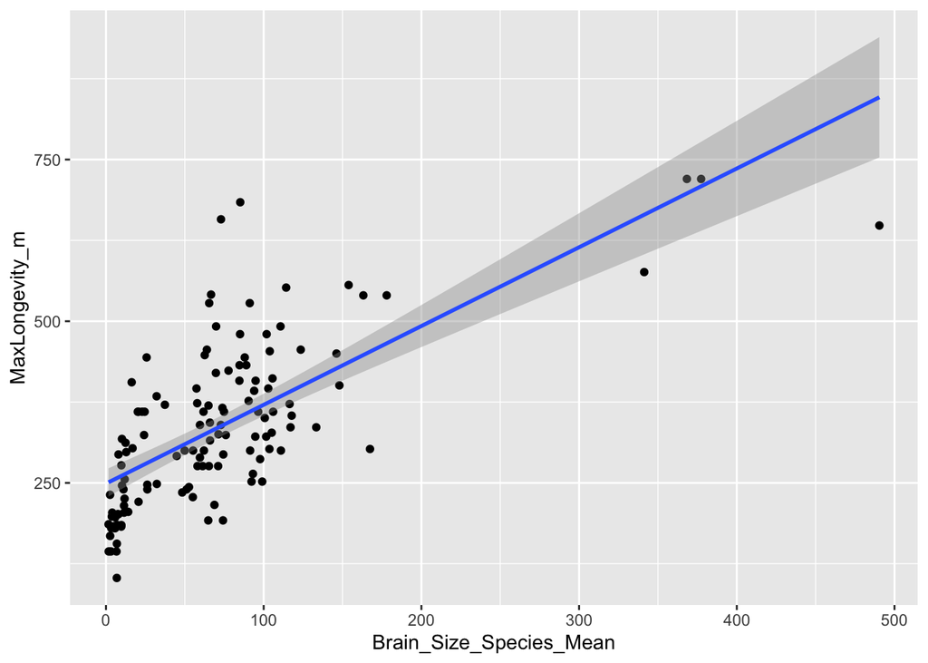

```r
pl <- ggplot(data = d, aes(x = Brain_Size_Species_Mean, y = MaxLongevity_m)) + geom_point() + geom_smooth(method = "lm", formula = y ~ x)
pl
```

As the brain size of the species increases by 1 gram, the longevity of the species is expected t increase by 1.218 months

```r
logmodel <- lm(data = d, log(MaxLongevity_m) ~ log(Brain_Size_Species_Mean) )
logmodel
```

```
##
## Call:
## lm(formula = log(MaxLongevity_m) ~ log(Brain_Size_Species_Mean),
##     data = d)
##
## Coefficients:
##                  (Intercept)  log(Brain_Size_Species_Mean)
##                       4.8790                        0.2341
```

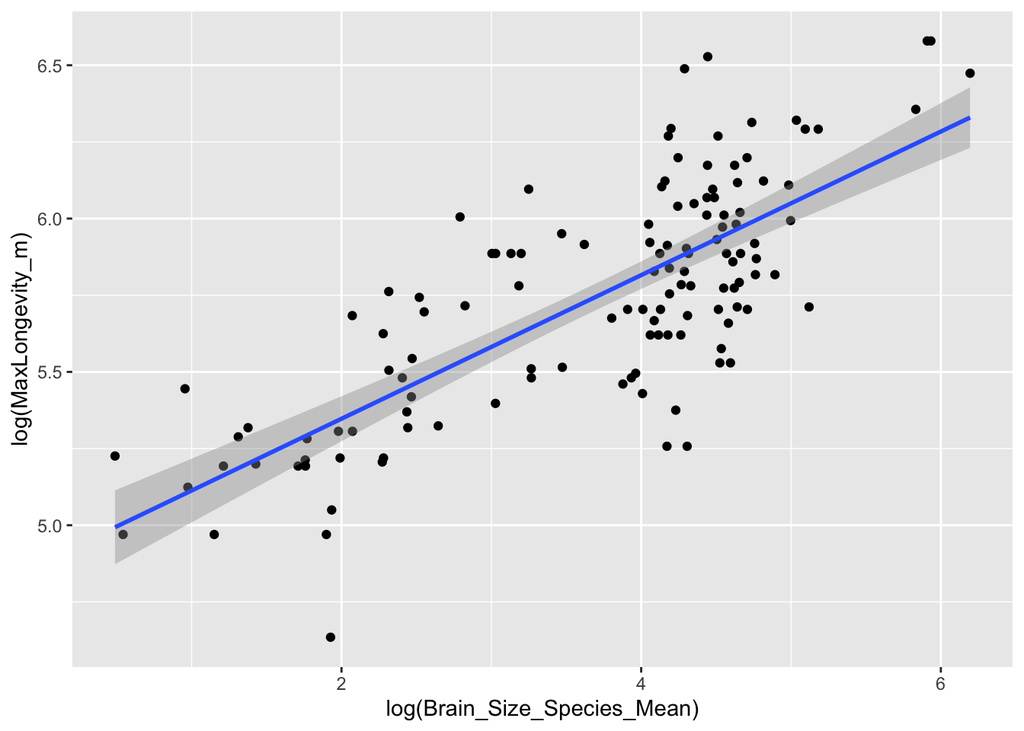

```r
plog <- ggplot(data = d, aes(x = log(Brain_Size_Species_Mean), y = log(MaxLongevity_m))) + geom_point() + geom_smooth(method = "lm", formula = y ~ x)
plog
```

As the log of the brain size of the species increases by 1 gram, the expected log of longevity is expected to increase by 0.2341 months.

When Beta1 is equal to 0, it means that when brain size of the species increases, there is no change in the longevity of the species.  
When Beta1 is not equal to 0, it means that there is a relationship between the species brain size and longevity.

```r
linmodel
```

```
##
## Call:
## lm(formula = MaxLongevity_m ~ Brain_Size_Species_Mean, data = d)
##
## Coefficients:
##             (Intercept)  Brain_Size_Species_Mean
##                 248.952                    1.218
```

```r
confint(linmodel, level = 0.90) # note that CI changes for each individual x, check out the confidence band in geom_smooth() output-Jimmy
```

```
##                                5 %      95 %
## (Intercept)             230.540738 267.36379
## Brain_Size_Species_Mean   1.035571   1.40041
```

CI of the slope of the untransformed model is [1.04, 1.40]

```r
confint(logmodel, level = 0.9)
```

```
##                                    5 %      95 %
## (Intercept)                  4.7644934 4.9934084
## log(Brain_Size_Species_Mean) 0.2046396 0.2636595
```

CI of log model is [0.205, 0.263]

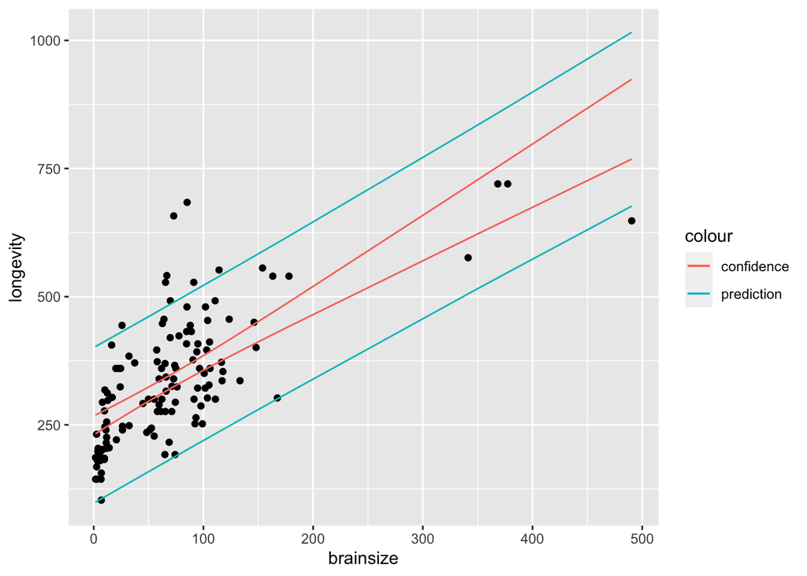

```r
lin.conf.int <- predict(linmodel, newdata = as.data.frame(x = d), interval = 'confidence', level = 0.90)
lin.prid.int <- predict(linmodel, newdata = as.data.frame(x = d), interval = 'prediction', level = 0.90)

log.conf.int <- predict(logmodel, newdata = as.data.frame(x = d), interval = 'confidence', level = 0.90)
log.prid.int <- predict(logmodel, newdata = as.data.frame(x = d), interval = 'prediction', level = 0.90)
#Used this(https://stackoverflow.com/questions/14069629/how-can-i-plot-data-with-confidence-intervals) but was struggling to make it work so had to modify it, I might have just done the wrong thing

df <- cbind.data.frame(d$Brain_Size_Species_Mean, d$MaxLongevity_m, lin.conf.int, lin.prid.int, log.conf.int, log.prid.int ) # ^ goodwork this looks correct-Jimmy
names(df) <- c("brainsize", "longevity", "conf.fit", "lci", "uci", "prid.fit", "prid.lower", "prid.higher", "log.conf.fit", "log.lci", "log.uci", "log.prid.fit", "log.prid.lower", "log.prid.upper")

linplot <- ggplot(data = df, aes(x = brainsize, y = longevity)) + geom_point() + geom_line(aes(x= brainsize, y = lci, colour = 'confidence')) + geom_line(aes(x= brainsize, y = uci, colour = 'confidence')) + geom_line(aes(x= brainsize, y = prid.lower, colour = 'prediction')) + geom_line(aes(x= brainsize, y = prid.higher, colour = 'prediction'))

linplot
```

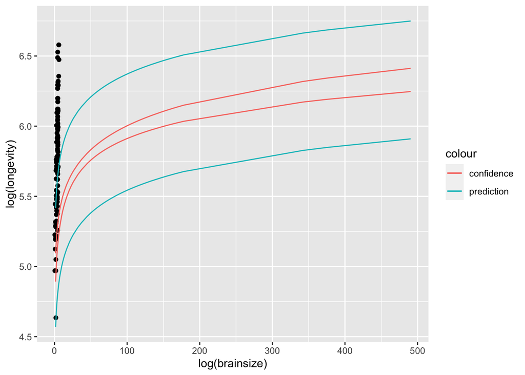

```r
logplot <- ggplot(data = df, aes(x = log(brainsize), y = log(longevity))) + geom_point() + geom_line(aes(x= brainsize, y = log.lci, colour = 'confidence')) + geom_line(aes(x= brainsize, y = log.uci, colour = 'confidence')) + geom_line(aes(x= brainsize, y = log.prid.lower, colour = 'prediction')) + geom_line(aes(x= brainsize, y = log.prid.upper, colour = 'prediction'))
logplot
```

```r
# make sure for geom_line() arguments that x = log(brainsize), otherwise looks good -Jimmy
```

I’m not sure what I’m doing wrong, did I forget a crucial step?

```r
point.est <- predict(linmodel, x =800, interval = 'confidence', level = 0.90) #check your "new_data" argument -Jimmy
point.est
```

```
##          fit      lwr      upr
## 1   319.6201 306.1354 333.1047
## 4   313.0551 299.3805 326.7297
## 6   309.7056 295.9081 323.5032
## 7   311.2281 297.4886 324.9676
## 8   316.2097 302.6349 329.7845
## 9   274.1281 258.0873 290.1690
## 11  268.8055 252.3068 285.3042
## 14  269.4754 253.0358 285.9150
## 16  257.3808 239.8173 274.9442
## 17  391.4815 375.6138 407.3492
## 18  388.0955 372.4979 403.6931
## 19  376.9509 362.1538 391.7479
## 20  375.4406 360.7408 390.1404
## 24  383.7594 368.4900 399.0289
```

[output cut: 114 more lines]

```r
point.est.log <- predict(logmodel, x = 800, interval = 'confidence', level = 0.90)
point.est.log
```

```
##          fit      lwr      upr
## 1   5.829783 5.791675 5.867891
## 4   5.806953 5.769598 5.844308
## 6   5.794387 5.757357 5.831416
## 7   5.800182 5.763011 5.837354
## 8   5.818201 5.780501 5.855901
## 9   5.588116 5.546999 5.629233
## 11  5.532501 5.487689 5.577313
## 14  5.540271 5.496024 5.584519
## 16  5.331894 5.268888 5.394899
## 17  5.994052 5.945582 6.042522
## 18  5.988422 5.940418 6.036426
## 19  5.968874 5.922439 6.015309
## 20  5.966095 5.919877 6.012313
## 24  5.981009 5.933609 6.028410
```

[output cut: 114 more lines]

In the grand scheme, I do not trust the models to predict observations for this value because values around 800g of brain were not considered for the linear regression models. The greatest data point is seen when x is around 500g. The model made can be used for data point’s whose mass is below 500g.

Between the 2 models, the logarithmic plot is better because it shows a more linear relationship compared to the plot of non-transformed data.